# "flat file" databases

Di Cook, Heike Hofmann  
2/21/2014

### Scenario

When data gets too big, databases don't work. Examples from the past:

- AT&T telecommunications network, all the calls made on the network
- email!
- Google File System (GFS)
- Hadoop derives from GFS

### Google File System

- Data is split into same size chunks, and distributed on different nodes.
- Indexes to the data help to find, and operate on the relevant chunks.
- Because nodes are cheap, configuration needs to have redundancies built in, in case of node failures.
- Not made freely available

[Source](http://en.wikipedia.org/wiki/Google_File_System)

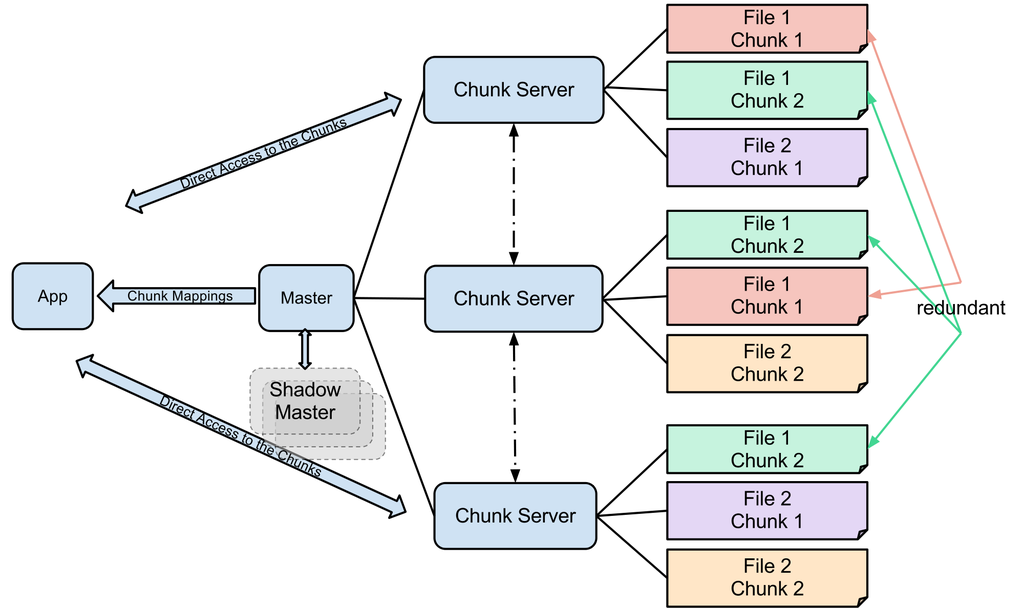

### Google File System

- A GFS cluster consists of multiple nodes. These nodes are divided into two types: one Master node and a large number of Chunkservers.
- Each file is divided into fixed-size chunks. Chunkservers store these chunks.
- Each chunk is assigned a unique 64-bit label by the master node at the time of creation, and logical mappings of files to constituent chunks are maintained.
- Each chunk is replicated several times throughout the network, with the minimum being three, but even more for files that have high end-in demand or need more redundancy.
- Master stores the metadata, that label chunk locations, what files the make up, where copies reside, and processes that enable reading and writing chunks.
- Metadata is kept current by the Master server periodically receiving updates from each chunk server (“Heart-beat messages”).
- Permissions for modifications are handled by a system of time-limited, expiring “leases”, where the Master server grants permission to a process for a finite period of time during which no other process will be granted permission by the Master server to modify the chunk.

### MapReduce

- Provides a programming layer over the distributed file system, for parallel distributed algorithm on the clusters.
- Map() procedure that performs filtering and sorting (such as sorting students by first name into queues, one queue for each name)
- Reduce() procedure that performs a summary operation (such as counting the number of students in each queue, yielding name frequencies

### Mail

[figure not shown]

- Flat file storage system
- Routines for reading, searching, editing,
- Indexed files to facilitate searching

### Mail

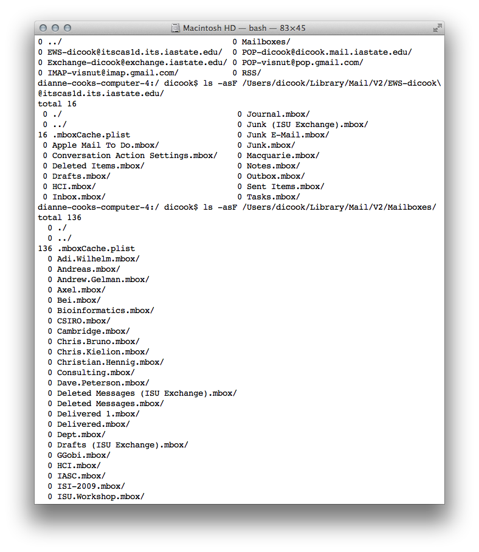

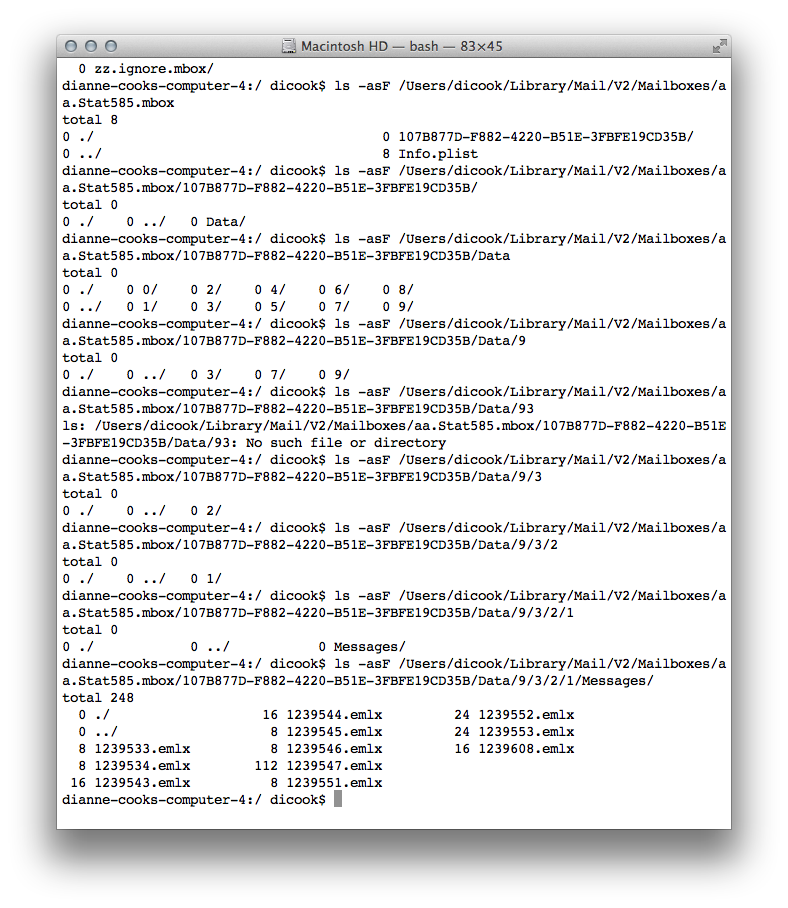

### Mail

Just flat files!

[figure not shown]

Mavericks OSX has problems indexing messages.

[figure not shown]

### Hadoop

- Hadoop Distributed File System (HDFS) is an open source system.
- Data is stored in a on multiple components, clusters.
- Based on GFS and MapReduce.

### Reading

Read this article and make a blog entry by 3pm Wednesday Feb 26.

[From S to R, and working with big data](http://www.research.att.com/articles/featured_stories/2013_09/201309_SandR.html?fbid=N9BG7vStkON)